# HW2

**Homework 2 Problem Statement** In this homework you will implement several versions of the perceptron algorithm and implement the fisher linear discriminant. In addition to this markdown file there is a another file called *perceptrons_functions_hw.R*, which contains helper functions and code stubs that need to be completed.

A good reference on perceptron algorithms is [The Perceptron Chapter by Hal Daume](http://ciml.info/dl/v0_99/ciml-v0_99-ch04.pdf)

Starting with this homework you will develop code in a .R file. Once you have debugged your code you will then use those functions to complete this markdown file.

**Step 1 Load functions** Create a chunk to do the following:

- Source the hw2_514.R file.
- Run ls.str to see which functions are loaded in your environment
- print.fun(‘name’) will print the named function. Use this function to display the code for print.fun and perceptron.box.data

```r
source('./hw2_514.R')
```

You can see the effect of sourcing by checking the objects in your environment using ls.str()

```r
ls.str()
```

```
## avg.perceptron.train : function (x, y, iter = 100)
## compute_vote : function (wgts, cs, bs, x)
## fisher : function (x, y)
## fisher.2d.line : function (w, m)
## freund.voted.perceptron.train : function (x, y, iter = 200)
## perceptron.box.data : function (n, gamma = 0.25, seed = NULL)
## perceptron.train : function (x, y, epoch = 100)
## plot.perceptron.box.data : function (data, title = "perceptron")
## predict.perceptron : function (w, b, x)
## predict.voted : function (wgts, cs, bs, x)
## print.fun : function (x)
## run.experiments : function (data, num.trials = 1, epochs = 100)
```

One of the helper functions provided is called *print.fun*. You use *print.fun* to display your code inside the markdown document. For example:

```r
print.fun('print.fun');
```

```
## [1] "print.fun (x) "
## {
##     header = deparse(args(x))[1]
##     b = body(x)
##     print(gsub("function", x, header))
##     print(b)
## }
```

```r
print.fun('perceptron.box.data');
```

```
## [1] "perceptron.box.data (n, gamma = 0.25, seed = NULL) "
## {
##     require(zeallot)
##     if (!is.null(seed))
##         set.seed(seed)
##     data = matrix(0, nrow = n, ncol = 3)
##     discriminant = function(x, y) {
##         (1 + x - y)/sqrt(2)
##     }
##     m = 0
##     while (m < n) {
##         x = runif(1, 0, 1)
##         y = runif(1, 0, 3)
##         d = discriminant(x, y)
##         d1 = d >= gamma
##         d2 = d <= -gamma
##         if (d1 & !d2) {
##             m = m + 1
##             data[m, ] %<-% c(x, y, +1)
##         }
##         else if (d2 & !d1) {
##             m = m + 1
##             data[m, ] %<-% c(x, y, -1)
##         }
##         else if (d1 & d2) {
##             m = m + 1
##             data[m, ] %<-% c(x, y, sample(c(-1, 1), 1))
##         }
##     }
##     data
## }
```

**Step 2 Create data**

Use the perceptron.box.data function to create a dataset of size 100 with gamma=0.05. Then plot the data. The gap between the datasets is 2*gamma.

```r
set.seed(123)
gamma=.05
data=perceptron.box.data(100,gamma);
```

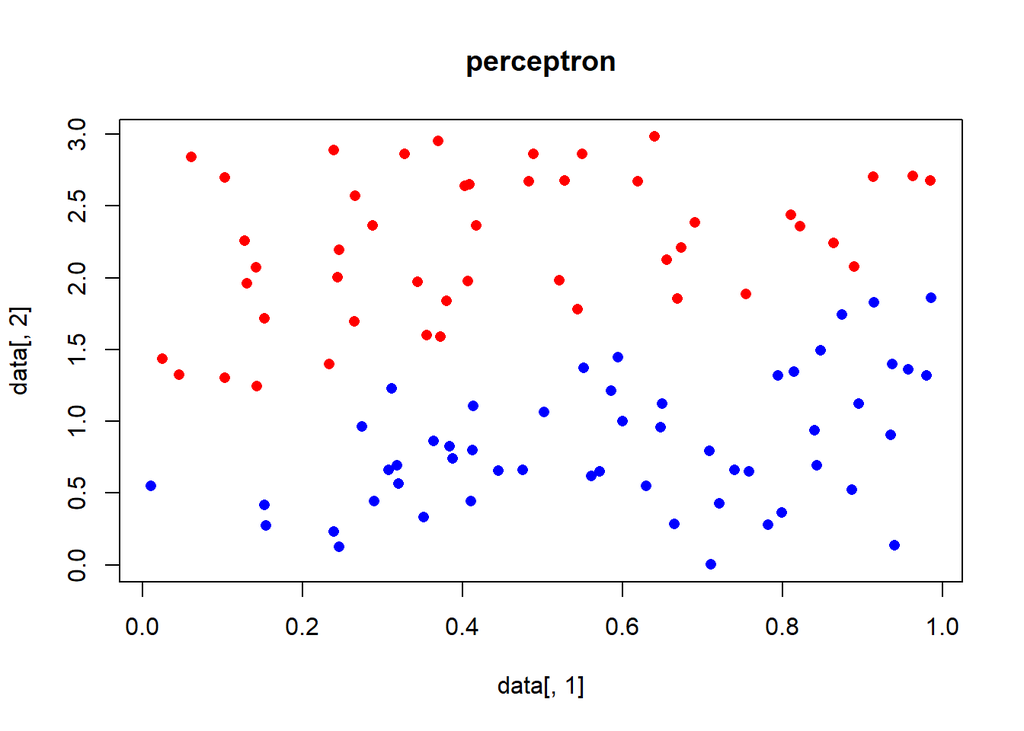

```r
plot.perceptron.box.data(data);
```

**Step 3 Write functions to train and test the vanilla perceptron**

Implement a function called train.perceptron that takes as input x data and an outcome y and number of epochs of training to be performed. This function will implement the perceptron training rule to adjust weights when mistakes are encountered and stop updating weights when no mistakes occur.

In addition implement a predict.perceptron function that takes input as w (weights returned from perceptron train), b (intercept learned from perceptron.train) and applies the learned weights to predict data x.

Use the gamma of .05 and number of observations of a 100 from step 2 to generate data for train and test.

Comments in the homework fill explain the inputs and outputs the functions should generate.

use the abline function in R to plot the decision boundary

```r
 y = data[,ncol(data)]
 x = data[,-ncol(data)]
```

```r
  gamma=.05
  test=perceptron.box.data(100,gamma);
```

**Step 5 Run experiments to test empirical bound on the number of mistakes perceptron makes**

Verify that the number of mistakes made by your perceptron training algorithm fall within the theoretical limits.

For gamma in *seq(.1,1,length.out = 10)*, train 10 models for each value of gamma and average the number of mistakes. Plot avg. number of mistakes vs theoretical limit of number of mistakes. Use 100 observations for each of the 100 datasets.

The Perceptron Convergence Proof shows that $\cfrac{R^2}{\gamma^2}$ where $R^2$ is the maximum euclidean norm of the observations in the data. The bound on mistakes is this $4 \frac{(\max \left \| x \right \|)^2}{\gamma^2}$

**Step 6 Implement voted perceptron** Implement the voted perceptron algorithm described in https://cseweb.ucsd.edu/~yfreund/papers/LargeMarginsUsingPerceptron.pdf . Implement the function called freund.voted.perceptron.train which has x,y, and number of epochs as input and returns a list called history which will contain the weights w, b intercept and cost based on survival time for weight change and also return the number of mistakes that occurred during training.

In addition implement the function predict.voted that will use the output of the voted algorithm and use it to classify a data set x.

Voted perceptron outputs an ensemble of weights and survival times which are used to made a decision. You might find it helpful to use more functions to make your code easy to debug.

```r
print.fun('freund.voted.perceptron.train');
```

[output not shown]

```r
data=perceptron.box.data(100,.1);
```

**Step 7 Average Perceptron** Implement the avg.perceptron.train function in the hw2_514.R file and test against same data out of sample and plot results. Use the same *predict.perceptron* function from earlier to test perceptron generated by avg.perceptron.train.

```r
print.fun('avg.perceptron.train');
```

[output not shown]

```r
 gamma=.05
  data=perceptron.box.data(100,gamma);
  y = data[,ncol(data)]
  x = data[,-ncol(data)]
```

**Step 8 Implement fisher discriminant function** Bishop’s section on Fisher discriminant might be useful to you: https://www.microsoft.com/en-us/research/uploads/prod/2006/01/Bishop-Pattern-Recognition-and-Machine-Learning-2006.pdf (page 186)

**Step 9 Compare fisher to vanilla and avg perceptron for non-separable data**

-Implement a function called fisher to compute the fisher discriminant using the equations documented above (step 8).The fisher function returns the direction vector w and the global mean for box data x, y.

```r
  print.fun('fisher')
```

```
## [1] "fisher (x, y) "
## {
##     return(list(w = w, m = m))
## }
```

```r
  data=perceptron.box.data(100,-.05);
  y = data[,ncol(data)]
  x = data[,-ncol(data)]
```

**Step 10 Write a margins function to compare the models**

Implement a function called margin that will compute the margin for the model on given data x using w,b. Use this function to compare the 3 models on out of sample data.

Which model seems to perform best (largest positive margin)?